# Week 2 Exercise

2026-02-08

# Group 2 members

- Jianyou Lee
- Saki Wakayama
- Henrietta Born
- Samuel Bahlinger

## Question 1

Test the hypothesis that the resilience of tree growth (resilience.biomass.production) depends on species richness in Spanish plots.

```r
#prepare data subset
spanish_plots <- subset(FunDivEurope, country == "Spain")

head(spanish_plots)
```

```
##     PlotId country annual.mean.temperature annual.mean.precipitation altitude
## 174  SPA02   Spain                     9.7                       545     1238
## 175  SPA03   Spain                     9.7                       549     1228
## 176  SPA04   Spain                     9.7                       549     1286
## 177  SPA05   Spain                     9.7                       549     1283
## 178  SPA06   Spain                     9.7                       549     1306
## 179  SPA07   Spain                     9.7                       548     1291
##     sand soil.depth age.distribution age.canopy.trees target.species.richness
## 174    1         20           uneven               NA                       3
## 175    1         20           uneven               NA                       2
## 176    1         50           uneven               NA                       2
## 177    1         70           uneven               NA                       2
## 178    1         30           uneven               NA                       2
## 179    1         30           uneven               NA                       2
##     species.composition Pielou.evenness prop.conifers tree.biomass.production
```

[output cut: 69 more lines]

```r
# Basic LM
lm.resilience <- lm(resilience.biomass.production ~ target.species.richness, data = spanish_plots)
summary(lm.resilience)
```

```
##
## Call:
## lm(formula = resilience.biomass.production ~ target.species.richness,
##     data = spanish_plots)
##
## Residuals:
##       Min        1Q    Median        3Q       Max
## -0.221679 -0.065904 -0.005516  0.081091  0.309962
##
## Coefficients:
##                         Estimate Std. Error t value Pr(>|t|)
## (Intercept)              0.94850    0.05076  18.685   <2e-16 ***
## target.species.richness  0.04975    0.02352   2.115   0.0421 *
## ---
## Signif. codes:  0 '***' 0.001 '**' 0.01 '*' 0.05 '.' 0.1 ' ' 1
##
## Residual standard error: 0.1222 on 33 degrees of freedom
## Multiple R-squared:  0.1194, Adjusted R-squared:  0.0927
## F-statistic: 4.474 on 1 and 33 DF,  p-value: 0.04206
```

Interpretation: Tree growth resilience increased significantly with increasing species richness in Spanish plots (linear model: p = 0.042).

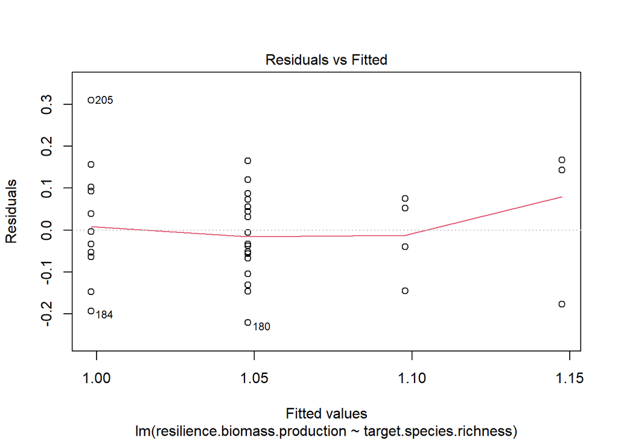

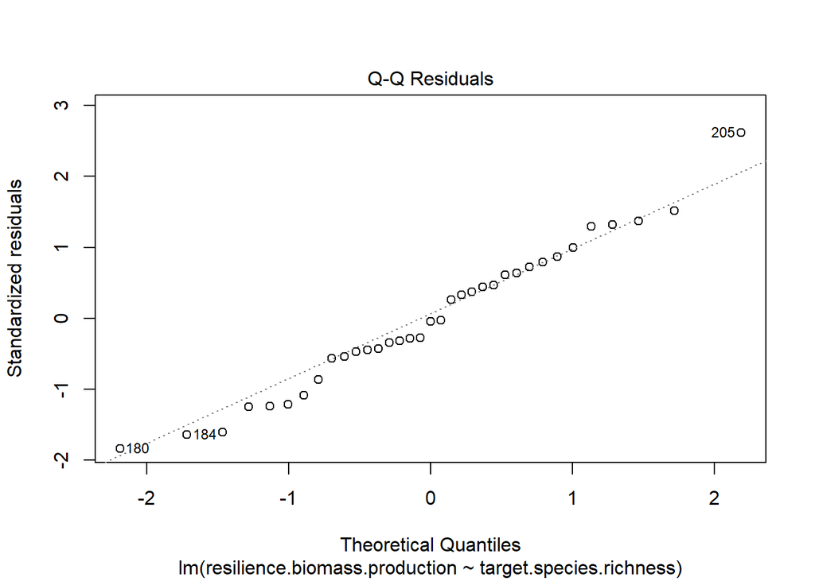

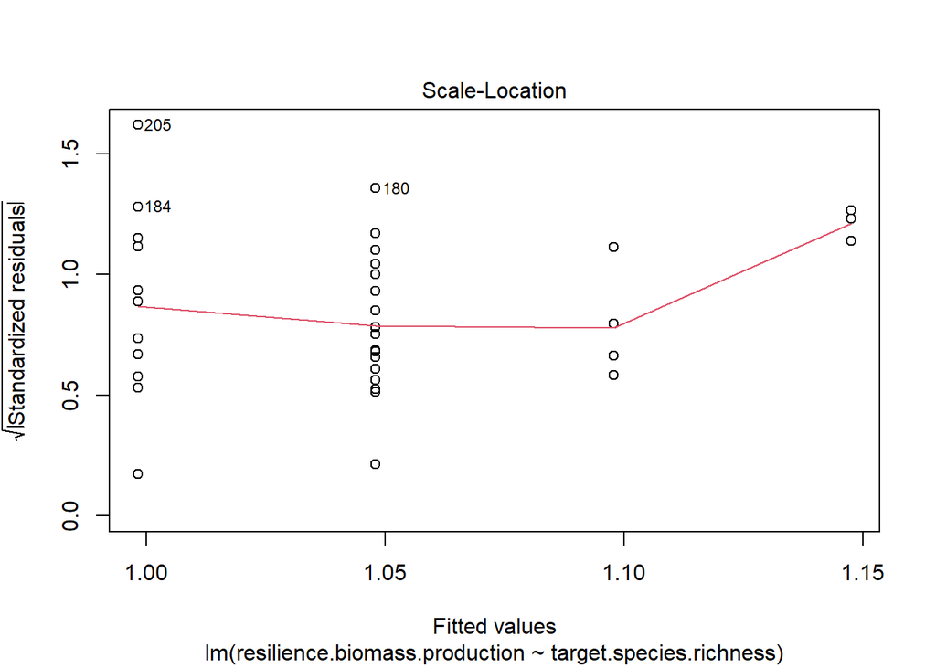

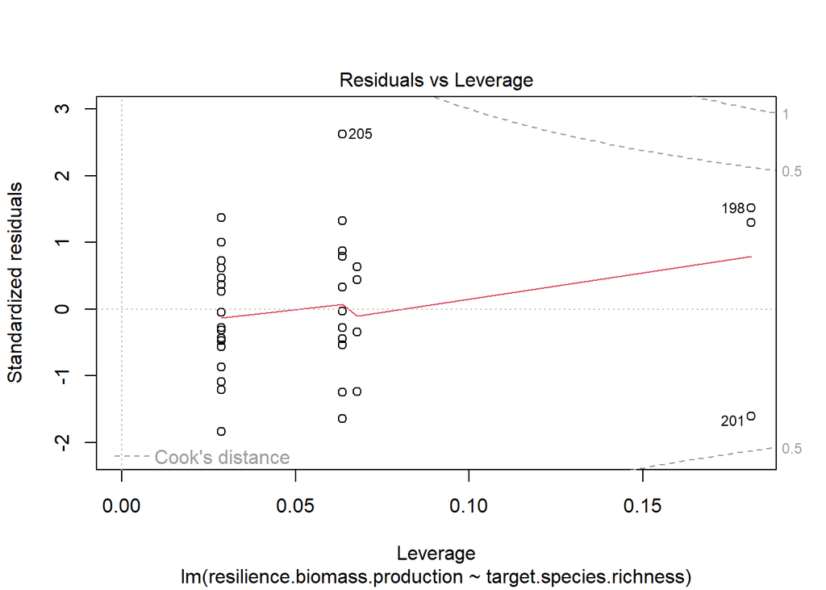

```r
#check residuals
plot(lm.resilience)
```

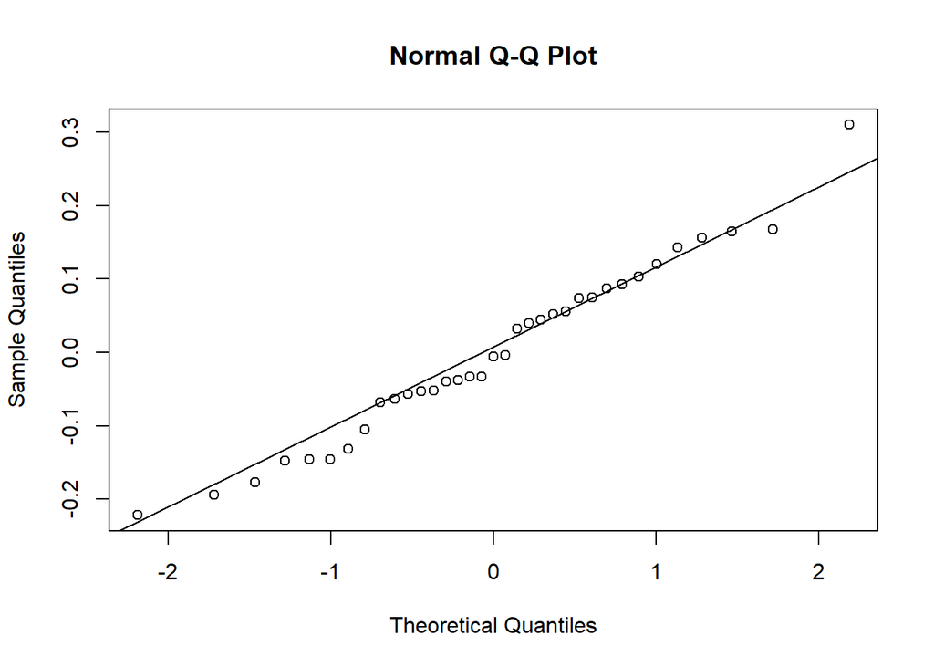

```r
qqnorm(resid(lm.resilience))
qqline(resid(lm.resilience))
```

```r
#homogenous
gls.resilience <- gls(resilience.biomass.production ~ target.species.richness,
                      data = spanish_plots,
                      weights = varIdent(form = ~1 | target.species.richness))
anova(gls.resilience)
```

```
## Denom. DF: 33
##                         numDF   F-value p-value
## (Intercept)                 1 2988.6678  <.0001
## target.species.richness     1    2.6721  0.1116
```

When accounting for heteroscedasticity using a generalized least squares model, the effect of species richness on resilience was no longer statistically significant (p = 0.11).

## Question 2

Test the hypothesis that the stability of tree growth depends on species richness (stability.biomass.production).

#Test the hypothesis that the stability of tree growth #depends on species richness (stability.biomass.production).

```r
# check the data tyoe of each predictor

for(var in names(data)){
  cat("Variable:", var, "\n")
  cat("  Class:", class(data[[var]]), "\n")
  cat("  Unique values:", length(unique(data[[var]])), "\n")
  cat("  First 5 values:", head(data[[var]],5), "\n\n")
}
```

```
## Variable: PlotId
##   Class: character
##   Unique values: 208
##   First 5 values: FIN01 FIN02 FIN03 FIN04 FIN05
##
## Variable: country
##   Class: character
##   Unique values: 6
##   First 5 values: Finland Finland Finland Finland Finland
##
## Variable: annual.mean.temperature
##   Class: numeric
##   Unique values: 59
##   First 5 values: 2.6 2.4 2.4 2.5 2.6
##
## Variable: annual.mean.precipitation
##   Class: integer
##   Unique values: 85
##   First 5 values: 625 638 638 637 631
##
## Variable: altitude
##   Class: numeric
##   Unique values: 180
##   First 5 values: 87 138 139 138 114
##
## Variable: sand
##   Class: integer
##   Unique values: 3
##   First 5 values: 1 1 1 1 1
##
## Variable: soil.depth
##   Class: integer
##   Unique values: 6
##   First 5 values: 80 80 80 80 70
##
## Variable: age.distribution
##   Class: character
##   Unique values: 2
##   First 5 values: even even even even even
##
```

[output cut: 134 more lines]

```
##
## Variable: litter.decomposition
##   Class: numeric
##   Unique values: 204
##   First 5 values: 0.5363631 0.5914471 0.5445249 0.8589871 0.6727053
##
## Variable: wood.decomposition
##   Class: numeric
##   Unique values: 208
##   First 5 values: 0.6981472 0.5756892 0.4983935 0.6736443 0.3946927
##
## Variable: soil.CN.ratio
##   Class: numeric
##   Unique values: 208
##   First 5 values: 21.53449 22.01535 20.29999 21.31824 27.33387
```

```r
#simple linear regression and check residual plot
m1 <- lm(stability.biomass.production ~ target.species.richness, data = data)


summary(m1)
```

```
##
## Call:
## lm(formula = stability.biomass.production ~ target.species.richness,
##     data = data)
##
## Residuals:
##     Min      1Q  Median      3Q     Max
## -3.5224 -1.0141 -0.1493  0.7190  5.7636
##
## Coefficients:
##                         Estimate Std. Error t value Pr(>|t|)
## (Intercept)               4.9635     0.2732  18.170  < 2e-16 ***
## target.species.richness   0.3882     0.1080   3.596 0.000405 ***
## ---
## Signif. codes:  0 '***' 0.001 '**' 0.01 '*' 0.05 '.' 0.1 ' ' 1
##
## Residual standard error: 1.581 on 204 degrees of freedom
##   (2 observations deleted due to missingness)
## Multiple R-squared:  0.05962,    Adjusted R-squared:  0.05501
## F-statistic: 12.93 on 1 and 204 DF,  p-value: 0.000405
```

```r
sum_stability_species.richness_lm <- summary(m1)
```

According to the model summary, the simple linear regression shows a significant positive relationship between target species richness and the stability of biomass production. However, the explanatory power of the model is low (R² = 0.0596, adjusted R² = 0.055), indicating that species richness alone explains only a small proportion of the variation in stability. This suggests that additional factors, such as country-level effects and interactions with other environmental variables, are likely to play an important role.

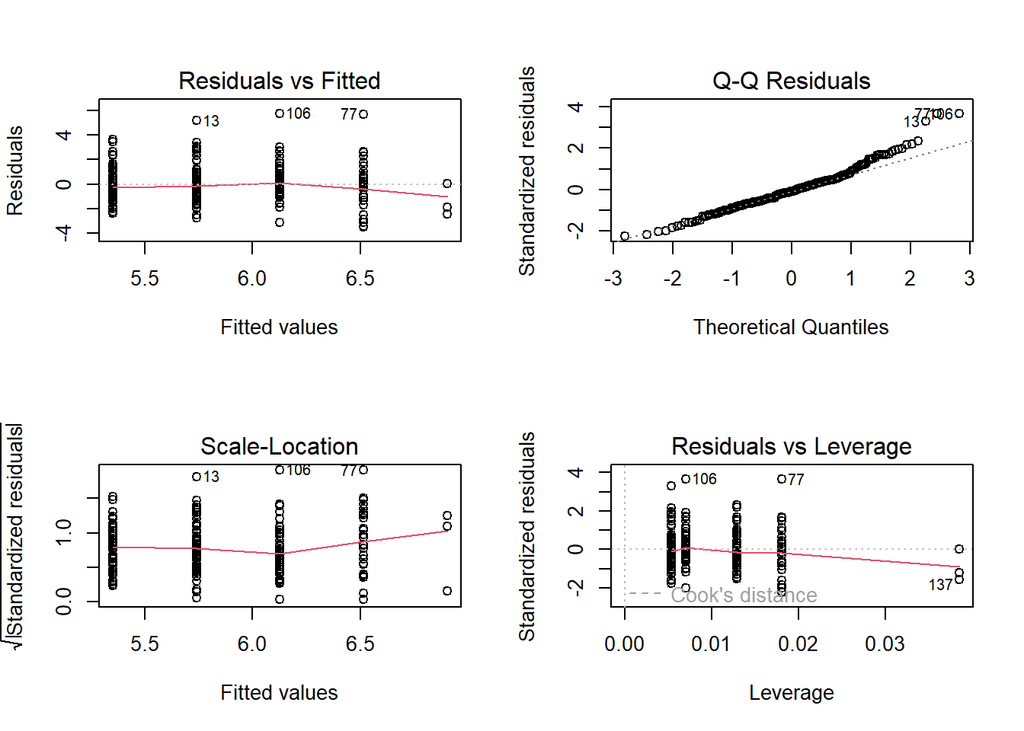

```r
par(mfrow = c(2,2))
plot(m1)
```

```r
par(mfrow = c(1,1))
```

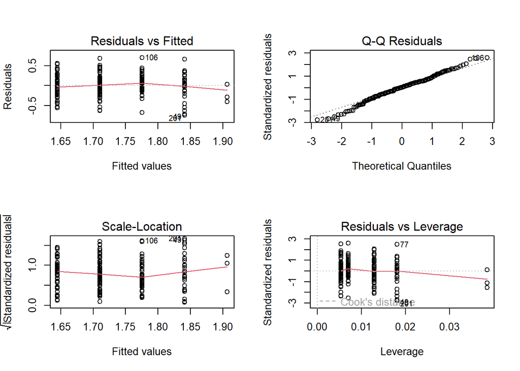

```r
#log transformation
data$log_stability <- log(data$stability.biomass.production)

m_log <- lm(log_stability ~ target.species.richness, data = data)
par(mfrow = c(2,2))
plot(m_log)
```

```r
summary(m_log)
```

```
##
## Call:
## lm(formula = log_stability ~ target.species.richness, data = data)
##
## Residuals:
##      Min       1Q   Median       3Q      Max
## -0.74437 -0.14971  0.01123  0.15578  0.70028
##
## Coefficients:
##                         Estimate Std. Error t value Pr(>|t|)
## (Intercept)              1.57929    0.04664   33.86  < 2e-16 ***
## target.species.richness  0.06543    0.01843    3.55 0.000479 ***
## ---
## Signif. codes:  0 '***' 0.001 '**' 0.01 '*' 0.05 '.' 0.1 ' ' 1
##
## Residual standard error: 0.2699 on 204 degrees of freedom
##   (2 observations deleted due to missingness)
## Multiple R-squared:  0.05817,    Adjusted R-squared:  0.05355
## F-statistic:  12.6 on 1 and 204 DF,  p-value: 0.000479
```

```r
sum_stability_species.richness_lm_log <- summary(m_log)



length(unique(data$target.species.richness))
```

```
## [1] 5
```

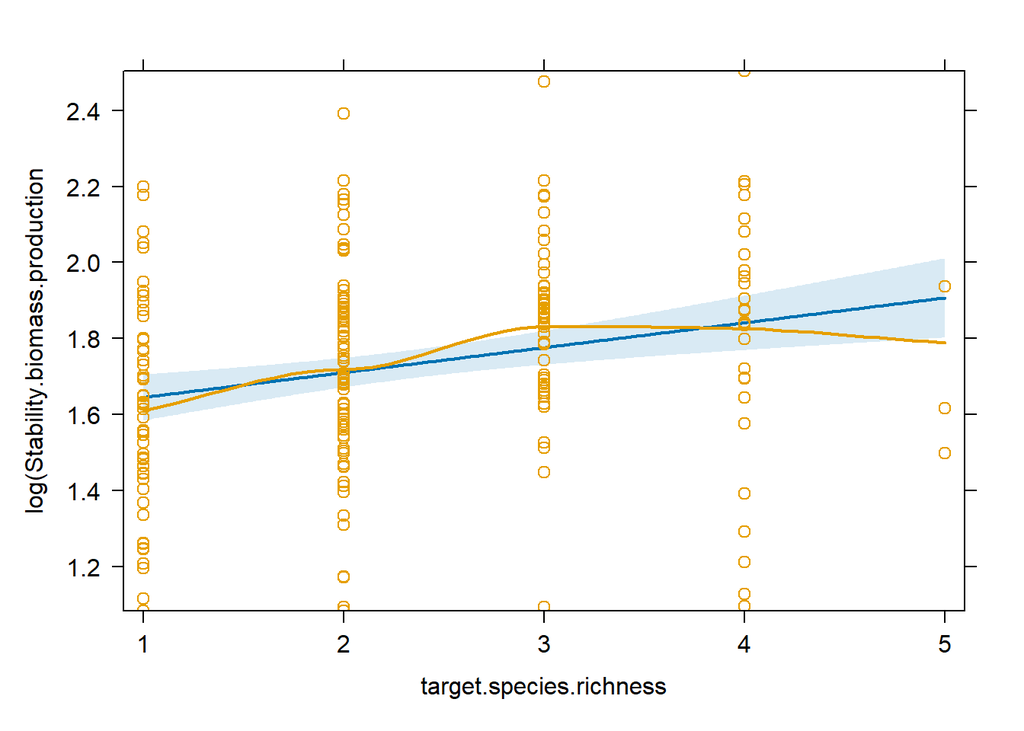

```r
library(effects)
eff_precip.lm <- effect("target.species.richness", m_log, partial.residuals = TRUE)
plot(eff_precip.lm,
     main = "",
     ylab = "log(Stability.biomass.production",
     xlab = "target.species.richness")
```

Log-transformed linear regression also showed a significant positive effect of target species richness on stability of biomass production (β = 0.065, p < 0.001). Model fit (R² ≈ 0.06) was nearly identical to the untransformed model, indicating that the inference is robust to log transformation.

target.species.richness => factor and ANOVA

```r
data$rich_f <- factor(data$target.species.richness)
data$log.soil.carbon <- log(data$soil.carbon)
m_aov <- aov(log_stability ~ rich_f, data = data)

summary(m_aov)
```

```
##              Df Sum Sq Mean Sq F value  Pr(>F)
## rich_f        4   1.30  0.3250   4.511 0.00164 **
## Residuals   201  14.48  0.0721
## ---
## Signif. codes:  0 '***' 0.001 '**' 0.01 '*' 0.05 '.' 0.1 ' ' 1
## 2 observations deleted due to missingness
```

```r
sum_stability_species.richness_aov <- summary(m_aov)

anova_sand <- lm(log.soil.carbon ~ sand, data = data)

emmeans(m_aov, pairwise ~ rich_f, adjust = "Tukey")
```

```
## $emmeans
##  rich_f emmean     SE  df lower.CL upper.CL
##  1        1.62 0.0383 201     1.54     1.69
##  2        1.71 0.0308 201     1.65     1.78
##  3        1.83 0.0376 201     1.76     1.90
##  4        1.80 0.0517 201     1.70     1.90
##  5        1.68 0.1550 201     1.38     1.99
##
## Confidence level used: 0.95
##
## $contrasts
##  contrast          estimate     SE  df t.ratio p.value
##  rich_f1 - rich_f2  -0.0982 0.0492 201  -1.997  0.2711
##  rich_f1 - rich_f3  -0.2133 0.0537 201  -3.972  0.0009
##  rich_f1 - rich_f4  -0.1848 0.0643 201  -2.872  0.0361
##  rich_f1 - rich_f5  -0.0671 0.1600 201  -0.420  0.9934
##  rich_f2 - rich_f3  -0.1151 0.0486 201  -2.368  0.1285
##  rich_f2 - rich_f4  -0.0865 0.0601 201  -1.439  0.6033
##  rich_f2 - rich_f5   0.0311 0.1580 201   0.197  0.9997
##  rich_f3 - rich_f4   0.0285 0.0639 201   0.446  0.9917
##  rich_f3 - rich_f5   0.1462 0.1590 201   0.916  0.8903
##  rich_f4 - rich_f5   0.1176 0.1630 201   0.720  0.9517
##
## P value adjustment: tukey method for comparing a family of 5 estimates
```

```r
emm_stability_species_richness <- emmeans(anova_sand, pairwise ~ sand, adjust = "Tukey")
```

One-way ANOVA on log-transformed stability showed significant differences among species richness levels (F(4, 201) = 4.51, p = 0.0016). Post-hoc comparisons indicated that stability at intermediate richness levels (three and four species) was significantly higher than at the lowest richness level, while differences among higher richness levels were not significant.

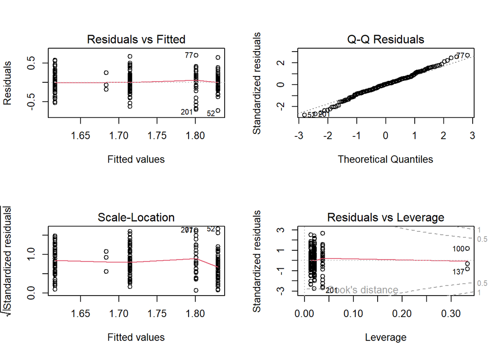

```r
par(mfrow = c(2,2))
plot(m_aov)
```

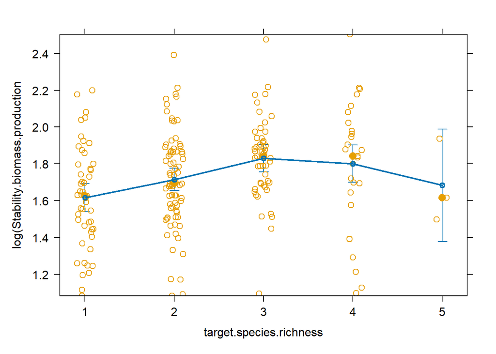

```r
par(mfrow = c(1,1))

library(ggplot2)

eff_precip.anova <- effect("rich_f", m_aov, partial.residuals = TRUE)
plot(eff_precip.anova,
     main = "",
     ylab = "log(Stability.biomass.production",
     xlab = "target.species.richness")
```

Nevertheless, large variation in stability of biomass production was observed within each species richness level in both the categorical and linear models. This suggests that additional factors beyond species richness are likely to be important, and that mixed-effects models incorporating other environmental variables and interaction terms should be considered.

effect of country as random effect

```r
library(lme4)
```

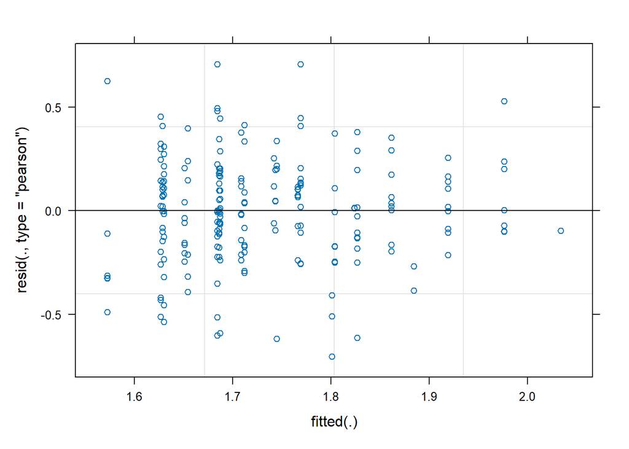

```r
m1.lmer <- lmer(
  log_stability ~ target.species.richness +
    (1 | country),
  data = data
)
par(mfrow = c(2,2))
plot(m1.lmer)
```

```r
par(mfrow = c(1,1))

summary(m1.lmer)
```

```
## Linear mixed model fit by REML ['lmerMod']
## Formula: log_stability ~ target.species.richness + (1 | country)
##    Data: data
##
## REML criterion at convergence: 44.4
##
## Scaled residuals:
##      Min       1Q   Median       3Q      Max
## -2.73211 -0.64598  0.01597  0.63243  2.74422
##
## Random effects:
##  Groups   Name        Variance Std.Dev.
##  country  (Intercept) 0.007702 0.08776
##  Residual             0.066456 0.25779
## Number of obs: 206, groups:  country, 6
##
## Fixed effects:
##                         Estimate Std. Error t value
## (Intercept)              1.59843    0.05841  27.365
## target.species.richness  0.05752    0.01861   3.091
##
## Correlation of Fixed Effects:
##             (Intr)
## trgt.spcs.r -0.726
```

```r
sum_stability_species.richness_country.effect_lmer <- summary(m1.lmer)
```

A linear mixed-effects model including country as a random effect confirmed a significant positive effect of target species richness on the stability of biomass production, indicating that the diversity effect is robust across countries.

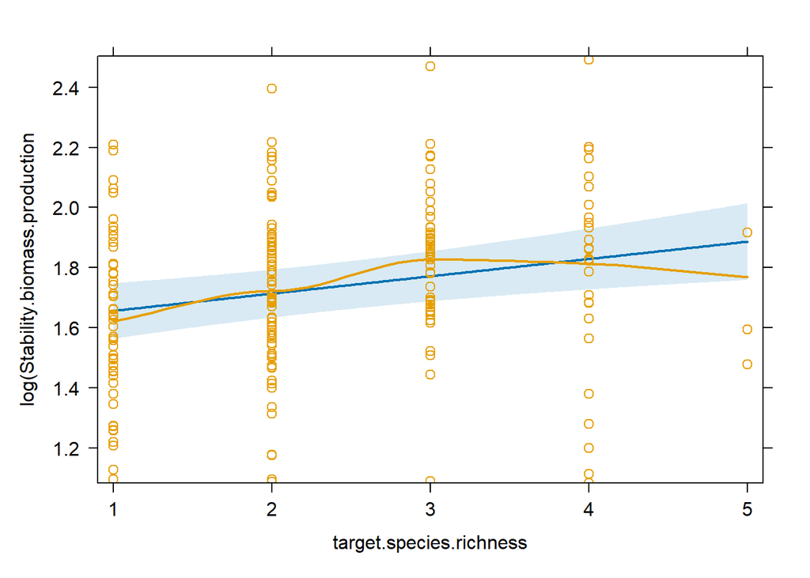

```r
eff_precip_mixlm <- effect("target.species.richness", m1.lmer, partial.residuals = TRUE)
plot(eff_precip_mixlm,
     main = "",
     ylab = "log(Stability.biomass.production",
     xlab = "target.species.richness")
```

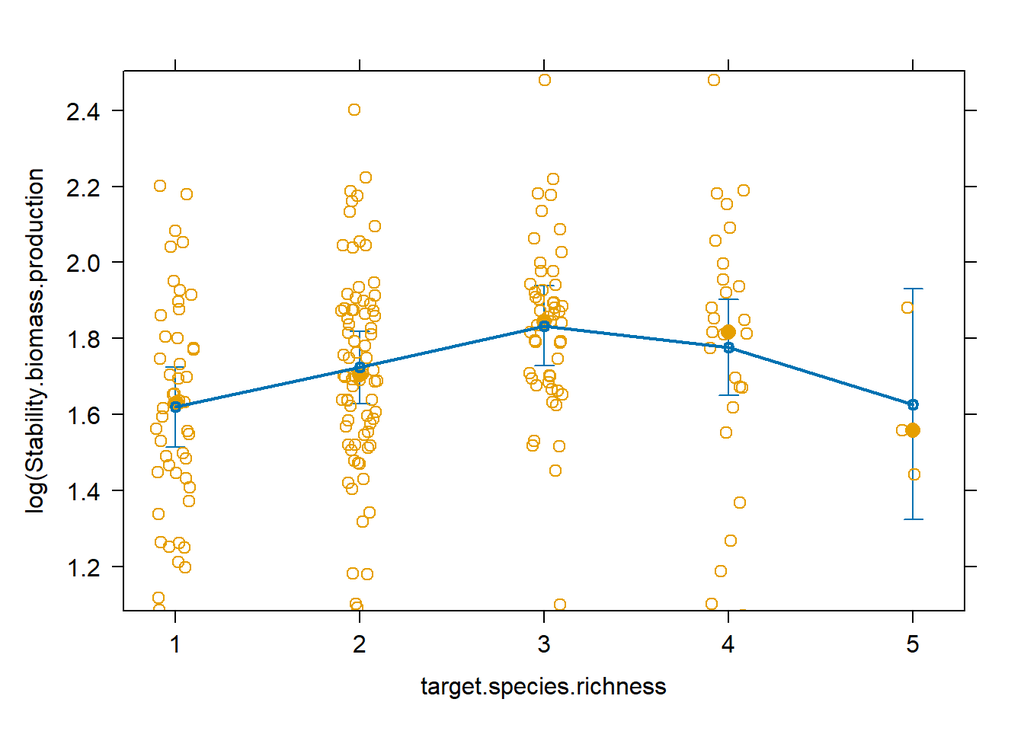

```r
m1.lmer.anovamix <- lmer(
  log_stability ~ rich_f +
    (1 | country),
  data = data
)

eff_precip.anovamix <- effect("rich_f", m1.lmer.anovamix, partial.residuals = TRUE)
plot(eff_precip.anovamix,
     main = "",
     ylab = "log(Stability.biomass.production",
     xlab = "target.species.richness")
```

## Question 3

Which country is most suitable for tree growth (tree.biomass.production)?

The most simple answer to compare, is a box and whisker plot of tree growth of different country

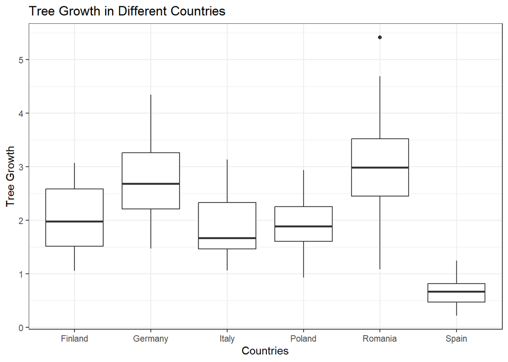

```r
# Select data of country, tree.biomass.production
best_country <- fundiv[,c("country", "tree.biomass.production")]
# make country as factors
best_country$country <- as.factor(best_country$country)

# boxplot
ggplot(best_country, aes(x = country, y = tree.biomass.production)) +
  geom_boxplot() +
  theme_bw() +
  labs(x = "Countries",
       y = "Tree Growth",
       title = "Tree Growth in Different Countries")
```

Seems like Germany and Romania has higher tree growth

```r
# Select data of Germany and Romania for comparison
tree.biomass.germany <- best_country %>% filter(country == "Germany")
tree.biomass.romania <- best_country %>% filter(country == "Romania")
summary(tree.biomass.germany)
```

```
##     country   tree.biomass.production
##  Finland: 0   Min.   :1.467
##  Germany:38   1st Qu.:2.211
##  Italy  : 0   Median :2.684
##  Poland : 0   Mean   :2.768
##  Romania: 0   3rd Qu.:3.259
##  Spain  : 0   Max.   :4.343
```

```r
summary(tree.biomass.romania)
```

```
##     country   tree.biomass.production
##  Finland: 0   Min.   :1.084
##  Germany: 0   1st Qu.:2.446
##  Italy  : 0   Median :2.981
##  Poland : 0   Mean   :3.027
##  Romania:28   3rd Qu.:3.516
##  Spain  : 0   Max.   :5.416
```

So from boxplot and just from mean and median, we can see Romania, at first glance, has the highest tree growth.

```r
# If I just want to compare if these two countries are significantly different
germany.romania <- rbind(tree.biomass.germany, tree.biomass.romania)
# check if I combined them correctly
nrow(germany.romania) == nrow(tree.biomass.germany) + nrow(tree.biomass.romania)
```

```
## [1] TRUE
```

```r
# compare variance just between germany and romania
anova(lm(tree.biomass.production ~ country, data = germany.romania))
```

```
## Analysis of Variance Table
##
## Response: tree.biomass.production
##           Df Sum Sq Mean Sq F value Pr(>F)
## country    1  1.081 1.08131  1.4677 0.2302
## Residuals 64 47.152 0.73675
```

Seems like there’s no significant difference between Germany and Romania in terms of tree growth.

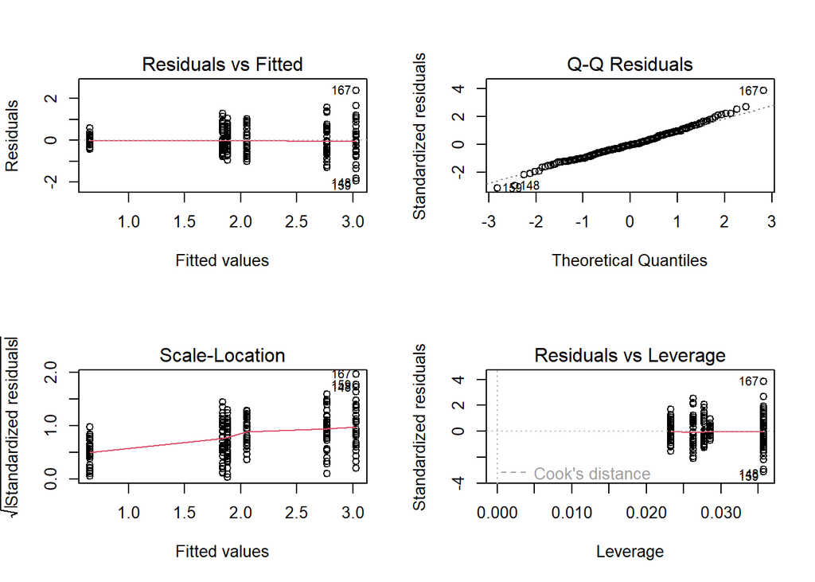

```r
# More analysis
# I am not sure if the other biomass.production is needed
#best.country <- fundiv[,c("country",
#                          "tree.biomass.production",
#                          "recovery.biomass.production",
#                          "resilience.biomass.production",
#                          "resistance.biomass.production",
#                          "stability.biomass.production")]
anova.best.country <- lm(tree.biomass.production ~ country , data = best_country)
par(mfrow = c(2, 2))
plot(anova.best.country)
```

```r
par(mfrow = c(1, 1))
```

Scale-Location plot shows the residuals are not entirely homoscedastic. Doesn’t matter because I only want to know which country has the highest tree growth, including and regardless other factors.

```r
anova(anova.best.country)
```

```
## Analysis of Variance Table
##
## Response: tree.biomass.production
##            Df Sum Sq Mean Sq F value    Pr(>F)
## country     5 116.78 23.3566  58.276 < 2.2e-16 ***
## Residuals 202  80.96  0.4008
## ---
## Signif. codes:  0 '***' 0.001 '**' 0.01 '*' 0.05 '.' 0.1 ' ' 1
```

```r
emmeans(anova.best.country, pairwise~country, adjust = "Tukey")
```

```
## $emmeans
##  country emmean     SE  df lower.CL upper.CL
##  Finland  2.056 0.1200 202    1.820    2.292
##  Germany  2.768 0.1030 202    2.565    2.970
##  Italy    1.841 0.1060 202    1.633    2.049
##  Poland   1.883 0.0965 202    1.693    2.073
##  Romania  3.027 0.1200 202    2.791    3.263
##  Spain    0.655 0.1070 202    0.444    0.866
##
## Confidence level used: 0.95
##
## $contrasts
##  contrast          estimate    SE  df t.ratio p.value
##  Finland - Germany  -0.7113 0.158 202  -4.511  0.0002
##  Finland - Italy     0.2153 0.160 202   1.350  0.7566
##  Finland - Poland    0.1733 0.154 202   1.127  0.8697
##  Finland - Romania  -0.9703 0.169 202  -5.735 <0.0001
##  Finland - Spain     1.4012 0.161 202   8.729 <0.0001
##  Germany - Italy     0.9267 0.147 202   6.293 <0.0001
##  Germany - Poland    0.8846 0.141 202   6.276 <0.0001
##  Germany - Romania  -0.2590 0.158 202  -1.643  0.5714
##  Germany - Spain     2.1125 0.148 202  14.243 <0.0001
##  Italy - Poland     -0.0421 0.143 202  -0.294  0.9997
##  Italy - Romania    -1.1857 0.160 202  -7.433 <0.0001
##  Italy - Spain       1.1859 0.150 202   7.891 <0.0001
##  Poland - Romania   -1.1436 0.154 202  -7.439 <0.0001
##  Poland - Spain      1.2279 0.144 202   8.520 <0.0001
##  Romania - Spain     2.3715 0.161 202  14.774 <0.0001
##
## P value adjustment: tukey method for comparing a family of 6 estimates
```

From the ANOVA and Post-hoc test (Tukey), we can see that Germany and Romania has significant difference compared to other countries in terms of tree growth. ($p < 0.001$)). Except, in between Germany and Romania, there’s no significant difference ($p = 0.57$).

## Question 4

Does the relationship between stability and tree species richness in Romanian forests differ among forests with even vs. uneven age distribution?

```r
library(tidyr)
library(ggplot2)
library(dplyr)
library(car)
library(tidyverse)
library(ggeffects)
library(effects)
library(patchwork)
```

```r
FunDivEUROPE <- read_csv("../Data/FunDivEUROPE.csv")
Fun <- FunDivEUROPE[, c("country","stability.biomass.production","target.species.richness","age.distribution")]
FunFilter <- Fun %>% filter(country == "Romania")
```

```r
head(FunFilter)
```

```
## # A tibble: 6 × 4
##   country stability.biomass.production target.species.richness age.distribution
##   <chr>                          <dbl>                   <dbl> <chr>
## 1 Romania                         4.24                       1 even
## 2 Romania                         5.43                       1 even
## 3 Romania                         6.47                       3 uneven
## 4 Romania                         4.47                       2 uneven
## 5 Romania                         6.45                       2 even
## 6 Romania                         4.46                       1 even
```

```r
str(FunFilter)
```

```
## tibble [28 × 4] (S3: tbl_df/tbl/data.frame)
##  $ country                     : chr [1:28] "Romania" "Romania" "Romania" "Romania" ...
##  $ stability.biomass.production: num [1:28] 4.24 5.43 6.47 4.47 6.45 ...
##  $ target.species.richness     : num [1:28] 1 1 3 2 2 1 4 2 3 3 ...
##  $ age.distribution            : chr [1:28] "even" "even" "uneven" "uneven" ...
```

```r
FunFilter$age.distribution <- factor(FunFilter$age.distribution) # age as factor
```

```r
Funancova <- lm(
  stability.biomass.production ~
    target.species.richness * age.distribution,
  data = FunFilter
)
```

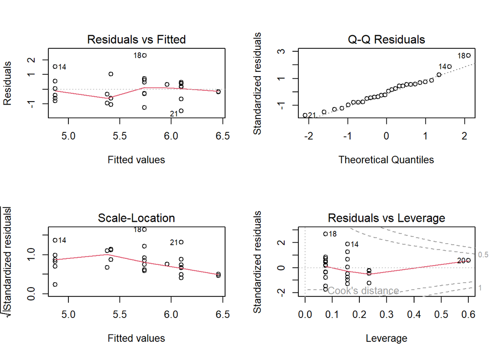

```r
par(mfrow = c(2,2))
plot(Funancova)
```

looks okay to me??

```r
summary(Funancova)
```

```
##
## Call:
## lm(formula = stability.biomass.production ~ target.species.richness *
##     age.distribution, data = FunFilter)
##
## Residuals:
##      Min       1Q   Median       3Q      Max
## -1.49062 -0.62042 -0.06237  0.47279  2.31144
##
## Coefficients:
##                                                Estimate Std. Error t value
## (Intercept)                                      4.3241     0.6931   6.239
## target.species.richness                          0.5451     0.4218   1.292
## age.distributionuneven                           0.6915     0.9618   0.719
## target.species.richness:age.distributionuneven  -0.1845     0.4919  -0.375
##                                                Pr(>|t|)
## (Intercept)                                     1.9e-06 ***
## target.species.richness                           0.209
## age.distributionuneven                            0.479
## target.species.richness:age.distributionuneven    0.711
## ---
## Signif. codes:  0 '***' 0.001 '**' 0.01 '*' 0.05 '.' 0.1 ' ' 1
##
## Residual standard error: 0.8947 on 24 degrees of freedom
## Multiple R-squared:  0.2622, Adjusted R-squared:   0.17
## F-statistic: 2.843 on 3 and 24 DF,  p-value: 0.05902
```

The effect of tree species richness on stability does not differ between even- and uneven-aged forests.

```r
anova(Funancova)
```

```
## Analysis of Variance Table
##
## Response: stability.biomass.production
##                                          Df  Sum Sq Mean Sq F value  Pr(>F)
## target.species.richness                   1  6.0911  6.0911  7.6085 0.01093 *
## age.distribution                          1  0.6245  0.6245  0.7801 0.38589
## target.species.richness:age.distribution  1  0.1126  0.1126  0.1407 0.71091
## Residuals                                24 19.2134  0.8006
## ---
## Signif. codes:  0 '***' 0.001 '**' 0.01 '*' 0.05 '.' 0.1 ' ' 1
```

### Conclusion

significant effect of species richness on stability of biomass production (F₁,₂₄ = 7.61, p = 0.011) The interaction between species richness and age was not significant (F₁,₂₄ = 0.14, p = 0.71) so the richness–stability relationship did not differ between even- and uneven-aged forests

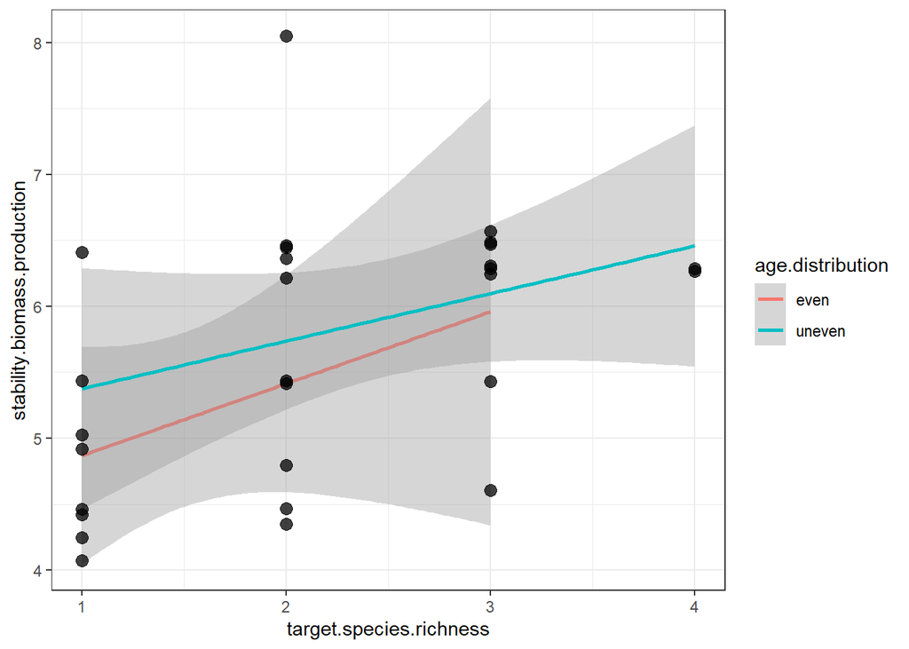

```r
plot.Fun <- ggplot(FunFilter, aes(y = stability.biomass.production, x = target.species.richness))+
  geom_smooth(method = lm,  aes(col = age.distribution)) +
  geom_point(
    shape = 21,
    size = 3,
    alpha = 0.75,
    fill = "black"
  ) +
  xlab("target.species.richness") +
  ylab("stability.biomass.production") +
  theme_bw()

plot.Fun
```

## Question 5 Test the hypothesis that soil carbon stock (soil.carbon) depends on species richness, altitude, sand cover, annual mean temperature, and precipitation.

# check the data tyoe of each predictor

```r
for(var in names(data)){
  cat("Variable:", var, "\n")
  cat("  Class:", class(data[[var]]), "\n")
  cat("  Unique values:", length(unique(data[[var]])), "\n")
  cat("  First 5 values:", head(data[[var]],5), "\n\n")
}
```

```
## Variable: PlotId
##   Class: character
##   Unique values: 208
##   First 5 values: FIN01 FIN02 FIN03 FIN04 FIN05
##
## Variable: country
##   Class: character
##   Unique values: 6
##   First 5 values: Finland Finland Finland Finland Finland
##
## Variable: annual.mean.temperature
##   Class: numeric
##   Unique values: 59
##   First 5 values: 2.6 2.4 2.4 2.5 2.6
##
## Variable: annual.mean.precipitation
##   Class: integer
##   Unique values: 85
##   First 5 values: 625 638 638 637 631
##
## Variable: altitude
##   Class: numeric
##   Unique values: 180
##   First 5 values: 87 138 139 138 114
##
## Variable: sand
##   Class: integer
##   Unique values: 3
##   First 5 values: 1 1 1 1 1
##
## Variable: soil.depth
##   Class: integer
##   Unique values: 6
##   First 5 values: 80 80 80 80 70
##
## Variable: age.distribution
##   Class: character
##   Unique values: 2
##   First 5 values: even even even even even
##
```

[output cut: 134 more lines]

```
##
## Variable: litter.decomposition
##   Class: numeric
##   Unique values: 204
##   First 5 values: 0.5363631 0.5914471 0.5445249 0.8589871 0.6727053
##
## Variable: wood.decomposition
##   Class: numeric
##   Unique values: 208
##   First 5 values: 0.6981472 0.5756892 0.4983935 0.6736443 0.3946927
##
## Variable: soil.CN.ratio
##   Class: numeric
##   Unique values: 208
##   First 5 values: 21.53449 22.01535 20.29999 21.31824 27.33387
```

with linear regression and check

```r
#transformation to factor of target species richness
data$target.species.richness <- as.factor(data$target.species.richness)
#transformation to factor of sand
data$sand <- as.factor(data$sand)

#try single linear regression and check statistic
lm.soilcarbon.tsr <- lm(soil.carbon ~ target.species.richness, data = data)
lm.soilcarbon.sd  <- lm(soil.carbon ~ sand, data = data)
lm.soilcarbon.altitude <- lm(soil.carbon ~ altitude, data = data)
lm.soilcarbon.temp <- lm(soil.carbon ~ annual.mean.temperature, data = data)
lm.soilcarbon.preci <- lm(soil.carbon ~ annual.mean.precipitation, data = data)
```

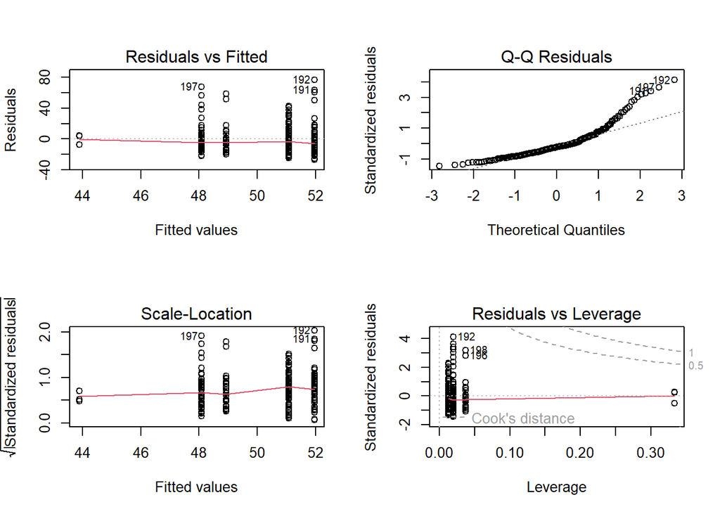

```r
#check model of target species richness
par(mfrow = c(2,2))
plot(lm.soilcarbon.tsr)
```

```r
par(mfrow = c(1,1))
```

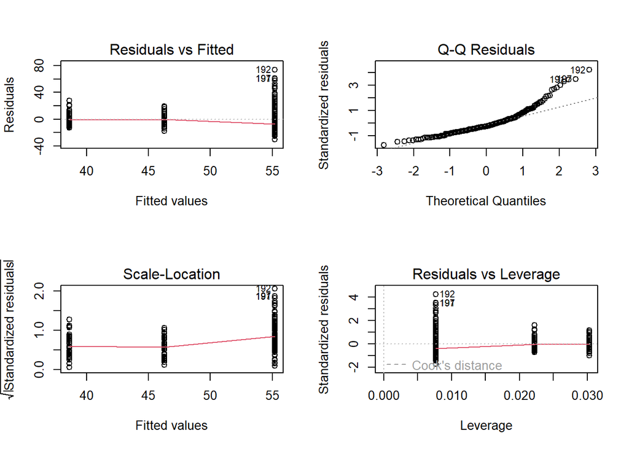

```r
# check sd
par(mfrow = c(2,2))
plot(lm.soilcarbon.sd)
```

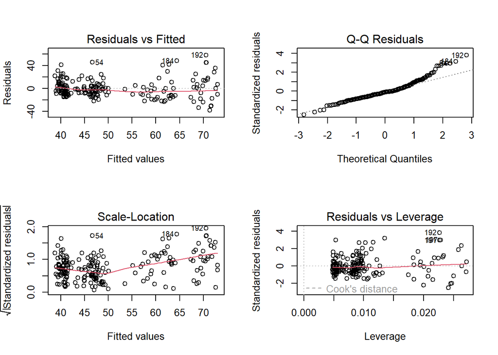

```r
par(mfrow = c(1,1))

#check altitude
par(mfrow = c(2,2))
plot(lm.soilcarbon.altitude)
```

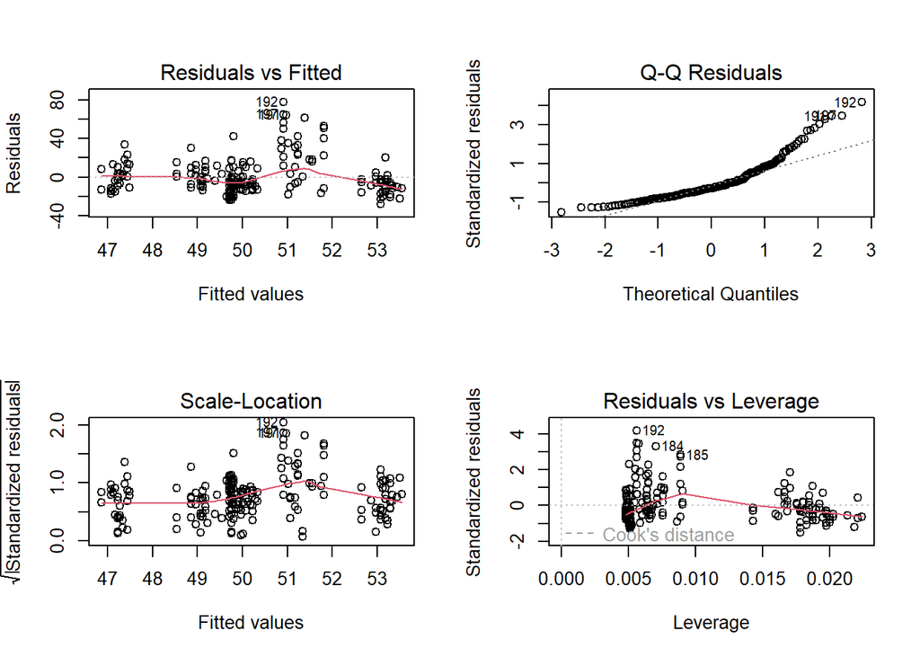

```r
par(mfrow = c(1,1))

#check temp
par(mfrow = c(2,2))
plot(lm.soilcarbon.temp)
```

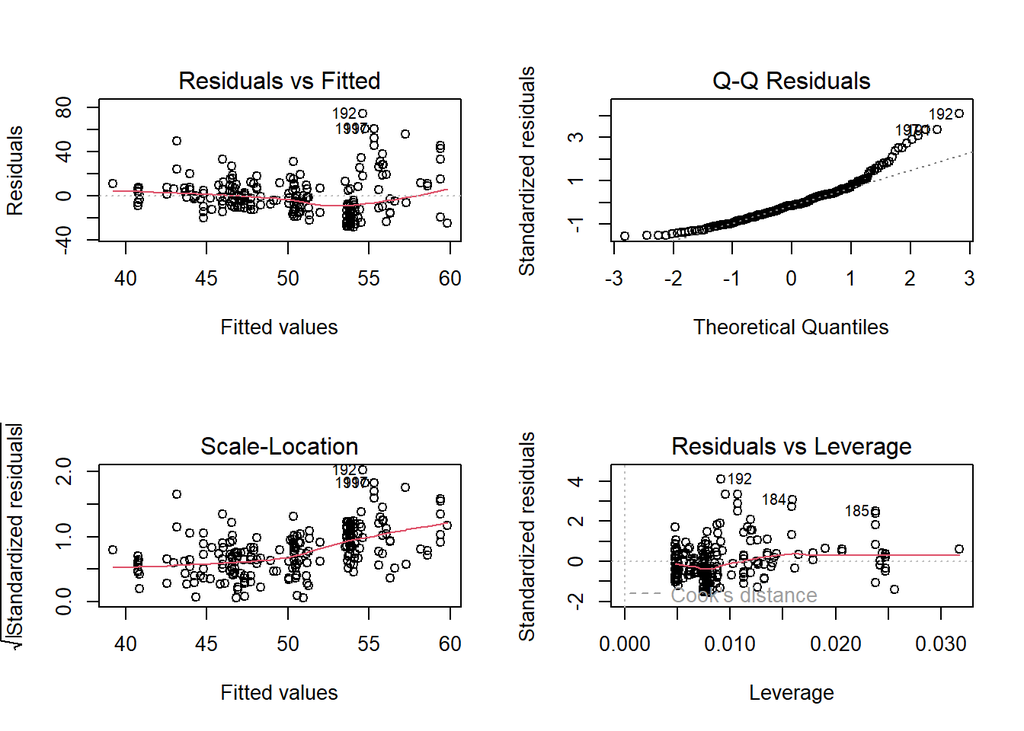

```r
par(mfrow = c(1,1))

#check prici
par(mfrow = c(2,2))
plot(lm.soilcarbon.preci)
```

```r
par(mfrow = c(1,1))
```

```r
#log transformation and try  again lm
min(data$soil.carbon, na.rm = TRUE)
```

```
## [1] 24.94704
```

```r
data$log.soil.carbon <- log(data$soil.carbon)

lm.sc.log.tsr <- lm(log.soil.carbon ~ target.species.richness, data = data)
lm.sc.log.sd  <- lm(log.soil.carbon ~ sand, data = data)
lm.sc.log.altitude <- lm(log.soil.carbon ~ altitude, data = data)
lm.sc.log.temp <- lm(log.soil.carbon ~ annual.mean.temperature, data = data)
lm.sc.log.preci <- lm(log.soil.carbon ~ annual.mean.precipitation, data = data)
```

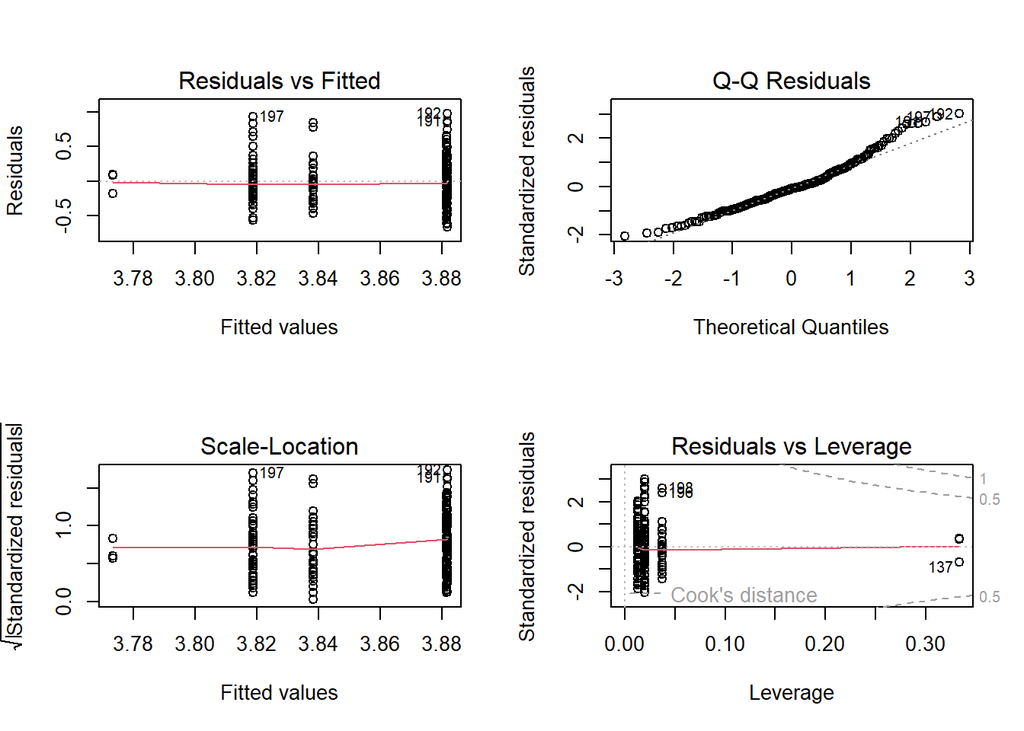

```r
#check model againl with log

#check model of target species richness
par(mfrow = c(2,2))
plot(lm.sc.log.tsr)
```

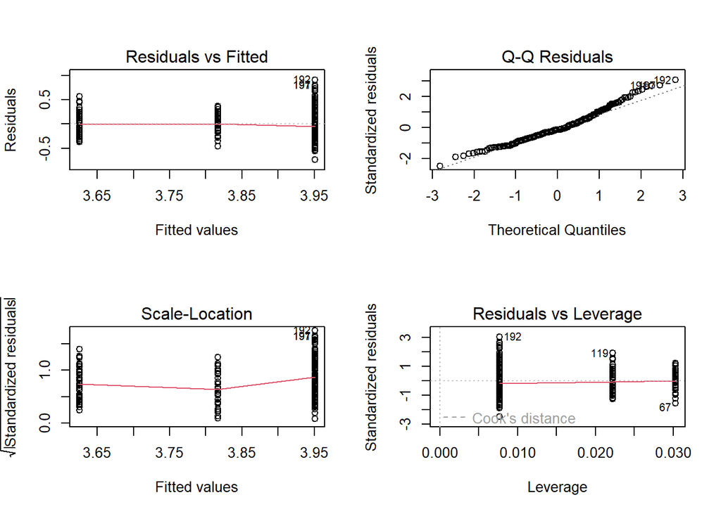

```r
par(mfrow = c(1,1))


# check sd
par(mfrow = c(2,2))
plot(lm.sc.log.sd)
```

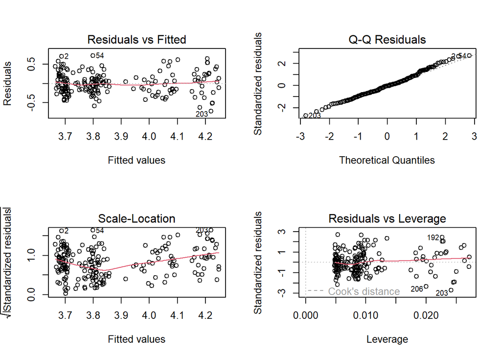

```r
par(mfrow = c(1,1))

#check altitude
par(mfrow = c(2,2))
plot(lm.sc.log.altitude)
```

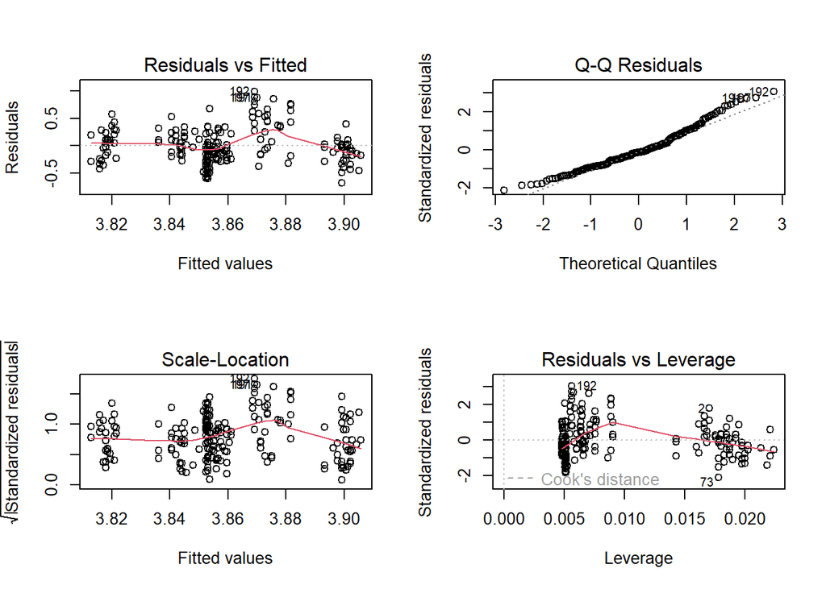

```r
par(mfrow = c(1,1))

#check temp
par(mfrow = c(2,2))
plot(lm.sc.log.temp)
```

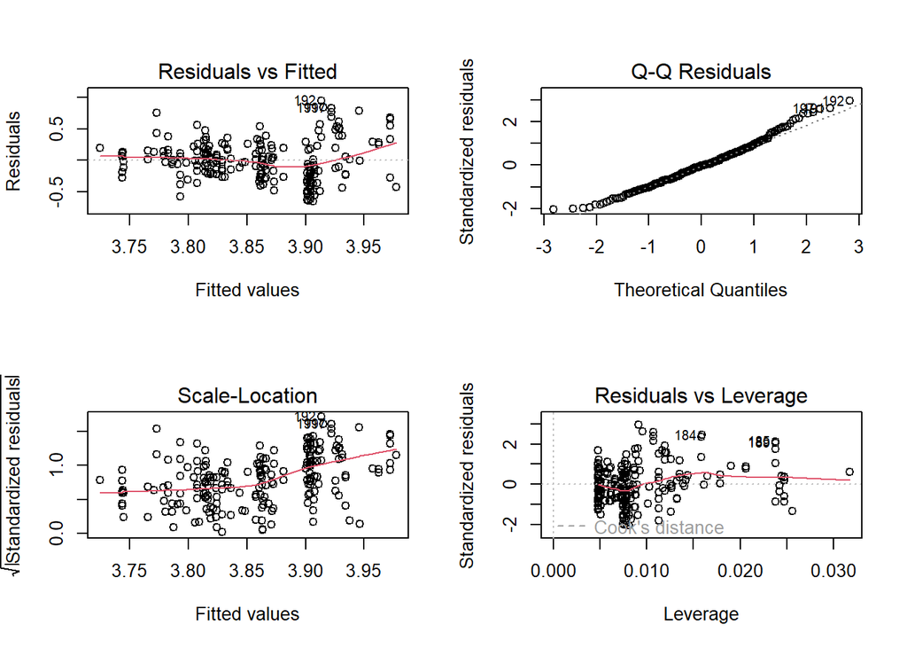

```r
par(mfrow = c(1,1))

#check prici
par(mfrow = c(2,2))
plot(lm.sc.log.preci)
```

```r
par(mfrow = c(1,1))
```

summary

```r
summary(lm.sc.log.tsr)
```

```
##
## Call:
## lm(formula = log.soil.carbon ~ target.species.richness, data = data)
##
## Residuals:
##      Min       1Q   Median       3Q      Max
## -0.66507 -0.21738 -0.02966  0.18290  0.97621
##
## Coefficients:
##                            Estimate Std. Error t value Pr(>|t|)
## (Intercept)               3.8818226  0.0457860  84.782   <2e-16 ***
## target.species.richness2 -0.0002144  0.0591872  -0.004    0.997
## target.species.richness3 -0.0631079  0.0647511  -0.975    0.331
## target.species.richness4 -0.0434293  0.0778212  -0.558    0.577
## target.species.richness5 -0.1086143  0.1942534  -0.559    0.577
## ---
## Signif. codes:  0 '***' 0.001 '**' 0.01 '*' 0.05 '.' 0.1 ' ' 1
##
## Residual standard error: 0.327 on 203 degrees of freedom
## Multiple R-squared:  0.008303,   Adjusted R-squared:  -0.01124
## F-statistic: 0.4249 on 4 and 203 DF,  p-value: 0.7905
```

```r
summary(lm.sc.log.tsr)
```

```
##
## Call:
## lm(formula = log.soil.carbon ~ target.species.richness, data = data)
##
## Residuals:
##      Min       1Q   Median       3Q      Max
## -0.66507 -0.21738 -0.02966  0.18290  0.97621
##
## Coefficients:
##                            Estimate Std. Error t value Pr(>|t|)
## (Intercept)               3.8818226  0.0457860  84.782   <2e-16 ***
## target.species.richness2 -0.0002144  0.0591872  -0.004    0.997
## target.species.richness3 -0.0631079  0.0647511  -0.975    0.331
## target.species.richness4 -0.0434293  0.0778212  -0.558    0.577
## target.species.richness5 -0.1086143  0.1942534  -0.559    0.577
## ---
## Signif. codes:  0 '***' 0.001 '**' 0.01 '*' 0.05 '.' 0.1 ' ' 1
##
## Residual standard error: 0.327 on 203 degrees of freedom
## Multiple R-squared:  0.008303,   Adjusted R-squared:  -0.01124
## F-statistic: 0.4249 on 4 and 203 DF,  p-value: 0.7905
```

The target species richness did not have a significant effect on soil carbon stock (F = 0.425, p = 0.79). The differences in predicted values among the richness levels were also not statistically significant. The overall explanatory power of the model was very low (R² = 0.008), suggesting that most of the variation in soil carbon is dependent on other factors.

```r
summary(lm.sc.log.sd)
```

```
##
## Call:
## lm(formula = log.soil.carbon ~ sand, data = data)
##
## Residuals:
##      Min       1Q   Median       3Q      Max
## -0.73407 -0.20205 -0.04042  0.16360  0.90720
##
## Coefficients:
##             Estimate Std. Error t value Pr(>|t|)
## (Intercept)  3.95083    0.02618 150.888  < 2e-16 ***
## sand2       -0.13447    0.05819  -2.311   0.0218 *
## sand3       -0.32554    0.05164  -6.305 1.74e-09 ***
## ---
## Signif. codes:  0 '***' 0.001 '**' 0.01 '*' 0.05 '.' 0.1 ' ' 1
##
## Residual standard error: 0.2985 on 205 degrees of freedom
## Multiple R-squared:  0.1651, Adjusted R-squared:  0.157
## F-statistic: 20.28 on 2 and 205 DF,  p-value: 9.234e-09
```

```r
summary(lm.sc.log.sd)
```

```
##
## Call:
## lm(formula = log.soil.carbon ~ sand, data = data)
##
## Residuals:
##      Min       1Q   Median       3Q      Max
## -0.73407 -0.20205 -0.04042  0.16360  0.90720
##
## Coefficients:
##             Estimate Std. Error t value Pr(>|t|)
## (Intercept)  3.95083    0.02618 150.888  < 2e-16 ***
## sand2       -0.13447    0.05819  -2.311   0.0218 *
## sand3       -0.32554    0.05164  -6.305 1.74e-09 ***
## ---
## Signif. codes:  0 '***' 0.001 '**' 0.01 '*' 0.05 '.' 0.1 ' ' 1
##
## Residual standard error: 0.2985 on 205 degrees of freedom
## Multiple R-squared:  0.1651, Adjusted R-squared:  0.157
## F-statistic: 20.28 on 2 and 205 DF,  p-value: 9.234e-09
```

The type of sand had a significant effect on soil carbon stock (F = 20.28, p < 0.001). Both sand2 and sand3 had significantly lower soil carbon compared to the reference sand type (sand1). The overall explanatory power of the model was 16%, indicating that sand type accounts for a portion of the variation in soil carbon.

```r
summary(lm.sc.log.altitude)
```

```
##
## Call:
## lm(formula = log.soil.carbon ~ altitude, data = data)
##
## Residuals:
##      Min       1Q   Median       3Q      Max
## -0.72330 -0.18621 -0.00731  0.15802  0.72762
##
## Coefficients:
##              Estimate Std. Error t value Pr(>|t|)
## (Intercept) 3.625e+00  3.074e-02 117.941   <2e-16 ***
## altitude    4.435e-04  4.618e-05   9.603   <2e-16 ***
## ---
## Signif. codes:  0 '***' 0.001 '**' 0.01 '*' 0.05 '.' 0.1 ' ' 1
##
## Residual standard error: 0.2709 on 206 degrees of freedom
## Multiple R-squared:  0.3092, Adjusted R-squared:  0.3059
## F-statistic: 92.21 on 1 and 206 DF,  p-value: < 2.2e-16
```

```r
summary(lm.sc.log.tsr)
```

```
##
## Call:
## lm(formula = log.soil.carbon ~ target.species.richness, data = data)
##
## Residuals:
##      Min       1Q   Median       3Q      Max
## -0.66507 -0.21738 -0.02966  0.18290  0.97621
##
## Coefficients:
##                            Estimate Std. Error t value Pr(>|t|)
## (Intercept)               3.8818226  0.0457860  84.782   <2e-16 ***
## target.species.richness2 -0.0002144  0.0591872  -0.004    0.997
## target.species.richness3 -0.0631079  0.0647511  -0.975    0.331
## target.species.richness4 -0.0434293  0.0778212  -0.558    0.577
## target.species.richness5 -0.1086143  0.1942534  -0.559    0.577
## ---
## Signif. codes:  0 '***' 0.001 '**' 0.01 '*' 0.05 '.' 0.1 ' ' 1
##
## Residual standard error: 0.327 on 203 degrees of freedom
## Multiple R-squared:  0.008303,   Adjusted R-squared:  -0.01124
## F-statistic: 0.4249 on 4 and 203 DF,  p-value: 0.7905
```

Altitude had a significant positive effect on soil carbon stock (F = 92.21, p < 0.001), with soil carbon increasing as altitude rises. The overall explanatory power of the model was approximately 31%, indicating that altitude accounts for a portion of the variation in soil carbon.

```r
summary(lm.sc.log.temp)
```

```
##
## Call:
## lm(formula = log.soil.carbon ~ annual.mean.temperature, data = data)
##
## Residuals:
##      Min       1Q   Median       3Q      Max
## -0.68244 -0.23637 -0.04327  0.18839  0.98888
##
## Coefficients:
##                         Estimate Std. Error t value Pr(>|t|)
## (Intercept)             3.802471   0.056850  66.886   <2e-16 ***
## annual.mean.temperature 0.007328   0.006758   1.084    0.279
## ---
## Signif. codes:  0 '***' 0.001 '**' 0.01 '*' 0.05 '.' 0.1 ' ' 1
##
## Residual standard error: 0.325 on 206 degrees of freedom
## Multiple R-squared:  0.005676,   Adjusted R-squared:  0.0008489
## F-statistic: 1.176 on 1 and 206 DF,  p-value: 0.2795
```

```r
summary(lm.sc.log.tsr)
```

```
##
## Call:
## lm(formula = log.soil.carbon ~ target.species.richness, data = data)
##
## Residuals:
##      Min       1Q   Median       3Q      Max
## -0.66507 -0.21738 -0.02966  0.18290  0.97621
##
## Coefficients:
##                            Estimate Std. Error t value Pr(>|t|)
## (Intercept)               3.8818226  0.0457860  84.782   <2e-16 ***
## target.species.richness2 -0.0002144  0.0591872  -0.004    0.997
## target.species.richness3 -0.0631079  0.0647511  -0.975    0.331
## target.species.richness4 -0.0434293  0.0778212  -0.558    0.577
## target.species.richness5 -0.1086143  0.1942534  -0.559    0.577
## ---
## Signif. codes:  0 '***' 0.001 '**' 0.01 '*' 0.05 '.' 0.1 ' ' 1
##
## Residual standard error: 0.327 on 203 degrees of freedom
## Multiple R-squared:  0.008303,   Adjusted R-squared:  -0.01124
## F-statistic: 0.4249 on 4 and 203 DF,  p-value: 0.7905
```

Annual mean temperature did not have a significant effect on soil carbon stock on its own (F = 1.176, p = 0.28). The overall explanatory power of the model was minimal (R² ≈ 0.006), indicating that variation in soil carbon cannot be explained by temperature alone.

```r
summary(lm.sc.log.preci)
```

```
##
## Call:
## lm(formula = log.soil.carbon ~ annual.mean.precipitation, data = data)
##
## Residuals:
##      Min       1Q   Median       3Q      Max
## -0.65144 -0.21954 -0.00894  0.18854  0.94476
##
## Coefficients:
##                             Estimate Std. Error t value Pr(>|t|)
## (Intercept)                4.3435781  0.1904715  22.804   <2e-16 ***
## annual.mean.precipitation -0.0007563  0.0002953  -2.561   0.0111 *
## ---
## Signif. codes:  0 '***' 0.001 '**' 0.01 '*' 0.05 '.' 0.1 ' ' 1
##
## Residual standard error: 0.3209 on 206 degrees of freedom
## Multiple R-squared:  0.03086,    Adjusted R-squared:  0.02616
## F-statistic:  6.56 on 1 and 206 DF,  p-value: 0.01114
```

```r
summary(lm.sc.log.tsr)
```

```
##
## Call:
## lm(formula = log.soil.carbon ~ target.species.richness, data = data)
##
## Residuals:
##      Min       1Q   Median       3Q      Max
## -0.66507 -0.21738 -0.02966  0.18290  0.97621
##
## Coefficients:
##                            Estimate Std. Error t value Pr(>|t|)
## (Intercept)               3.8818226  0.0457860  84.782   <2e-16 ***
## target.species.richness2 -0.0002144  0.0591872  -0.004    0.997
## target.species.richness3 -0.0631079  0.0647511  -0.975    0.331
## target.species.richness4 -0.0434293  0.0778212  -0.558    0.577
## target.species.richness5 -0.1086143  0.1942534  -0.559    0.577
## ---
## Signif. codes:  0 '***' 0.001 '**' 0.01 '*' 0.05 '.' 0.1 ' ' 1
##
## Residual standard error: 0.327 on 203 degrees of freedom
## Multiple R-squared:  0.008303,   Adjusted R-squared:  -0.01124
## F-statistic: 0.4249 on 4 and 203 DF,  p-value: 0.7905
```

Annual mean precipitation had a small but significant negative effect on soil carbon stock (β = -0.00076, p = 0.011). The overall explanatory power of the model was low (R² ≈ 0.03), indicating that precipitation alone cannot account for most of the variation in soil carbon.

Based on the results so far, species richness, temperature, and precipitation cannot be considered as primary explanatory variables for soil carbon on their own. In contrast, altitude and sand type appear to have the potential to act as major single factors influencing soil carbon. Therefore, a base model using altitude and sand as fixed effects should first be constructed, and the distribution of the residuals should be re-examined. After that, models incorporating interaction effects and random effects can be created, visualized, and tested separately.

sand, atitude model

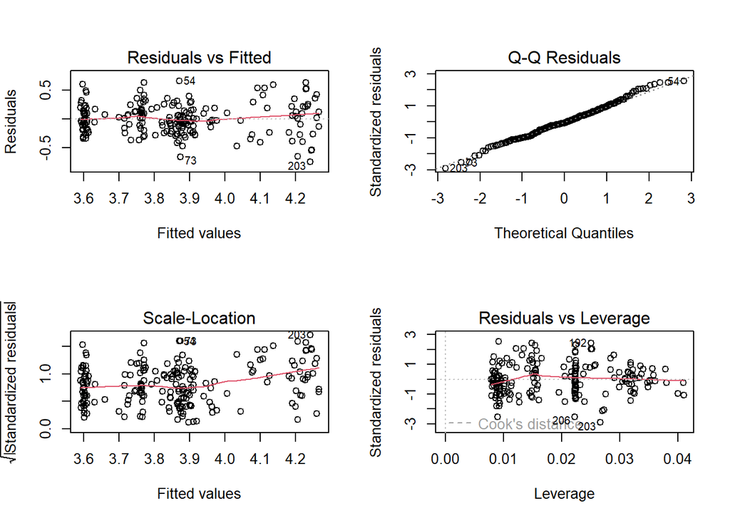

```r
lm.sd.at <- lm(log.soil.carbon ~ sand + altitude, data = data)

par(mfrow = c(2, 2))
plot(lm.sd.at)
```

```r
summary(lm.sd.at)
```

```
##
## Call:
## lm(formula = log.soil.carbon ~ sand + altitude, data = data)
##
## Residuals:
##      Min       1Q   Median       3Q      Max
## -0.74542 -0.17410 -0.02034  0.15815  0.65655
##
## Coefficients:
##               Estimate Std. Error t value Pr(>|t|)
## (Intercept)  3.717e+00  3.664e-02 101.447  < 2e-16 ***
## sand2       -1.563e-01  5.072e-02  -3.082 0.002342 **
## sand3       -1.817e-01  4.827e-02  -3.764 0.000218 ***
## altitude     3.920e-04  4.802e-05   8.163 3.34e-14 ***
## ---
## Signif. codes:  0 '***' 0.001 '**' 0.01 '*' 0.05 '.' 0.1 ' ' 1
##
## Residual standard error: 0.2598 on 204 degrees of freedom
## Multiple R-squared:  0.3707, Adjusted R-squared:  0.3614
## F-statistic: 40.06 on 3 and 204 DF,  p-value: < 2.2e-16
```

```r
lm.sd.at.int <- lm(log.soil.carbon ~ sand * altitude, data = data)
anova(lm.sd.at, lm.sd.at.int)
```

```
## Analysis of Variance Table
##
## Model 1: log.soil.carbon ~ sand + altitude
## Model 2: log.soil.carbon ~ sand * altitude
##   Res.Df    RSS Df Sum of Sq      F Pr(>F)
## 1    204 13.772
## 2    202 13.746  2  0.026088 0.1917 0.8257
```

No interaction was detected between sand and altitude. Adding the sand × altitude interaction to the model did not significantly improve it (F = 0.192, p = 0.826). Therefore, the effects of sand and altitude on soil carbon stock can be adequately explained by their main effects alone.

about precipitation

```r
lm.base <- lm(log.soil.carbon ~ sand + altitude, data = data)
lm.p <- lm(log.soil.carbon ~ sand + altitude + annual.mean.precipitation, data = data)
anova(lm.base, lm.p)
```

```
## Analysis of Variance Table
##
## Model 1: log.soil.carbon ~ sand + altitude
## Model 2: log.soil.carbon ~ sand + altitude + annual.mean.precipitation
##   Res.Df    RSS Df Sum of Sq      F  Pr(>F)
## 1    204 13.772
## 2    203 13.521  1   0.25129 3.7727 0.05348 .
## ---
## Signif. codes:  0 '***' 0.001 '**' 0.01 '*' 0.05 '.' 0.1 ' ' 1
```

```r
anova(lm.base, lm.p)
```

```
## Analysis of Variance Table
##
## Model 1: log.soil.carbon ~ sand + altitude
## Model 2: log.soil.carbon ~ sand + altitude + annual.mean.precipitation
##   Res.Df    RSS Df Sum of Sq      F  Pr(>F)
## 1    204 13.772
## 2    203 13.521  1   0.25129 3.7727 0.05348 .
## ---
## Signif. codes:  0 '***' 0.001 '**' 0.01 '*' 0.05 '.' 0.1 ' ' 1
```

The effect of annual mean precipitation on soil carbon is only marginally significant, but considering potential influences of random effects, it will be retained as a fixed effect.

Step 1: Visualization of the Base Model with Fixed Effects

The fixed effects to be included are:

Sand (categorical variable)

Altitude (continuous variable)

Annual mean precipitation (continuous variable)

This base model will allow us to visualize the relationships of these key predictors with soil carbon before adding interaction or random effects.

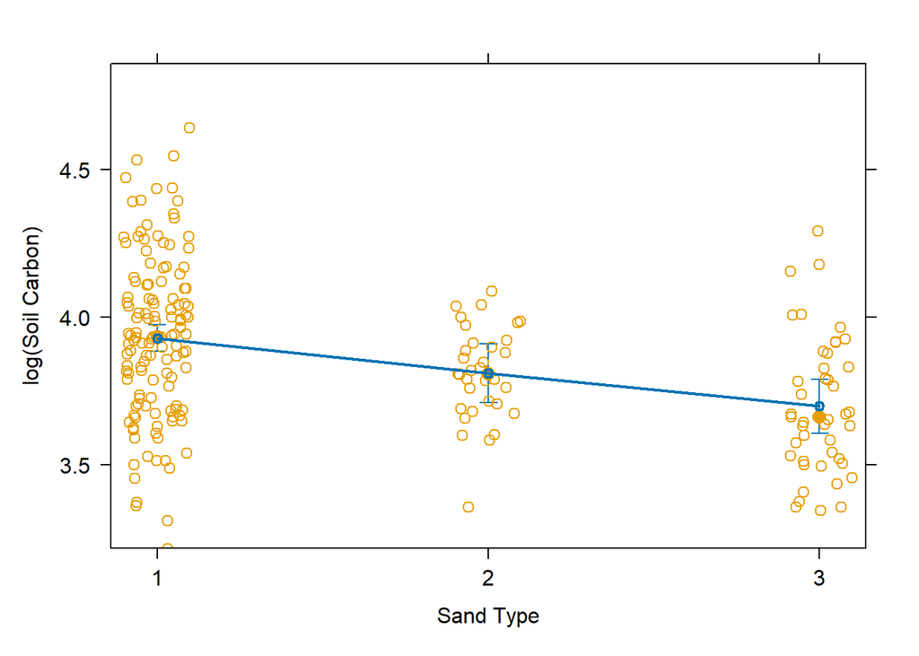

```r
library(effects)


m_base <- lm(log.soil.carbon ~ sand + altitude + annual.mean.precipitation, data = data)


eff_sand <- effect("sand", m_base, partial.residuals = TRUE)


plot(eff_sand,
     main = "",
     ylab = "log(Soil Carbon)",
     xlab = "Sand Type")
```